# Statistical linear regression models

Brian Caffo, Jeff Leek, Roger Peng

## Basic regression model with additive Gaussian errors.

- Least squares is an estimation tool, how do we do inference?
- Consider developing a probabilistic model for linear regression $Y_i = \beta_0 + \beta_1 X_i + \epsilon_{i}$
- Here the $\epsilon_{i}$ are assumed iid $N(0, \sigma^2)$.
- Note, $E[Y_i ~|~ X_i = x_i] = \mu_i = \beta_0 + \beta_1 x_i$
- Note, $Var(Y_i ~|~ X_i = x_i) = \sigma^2$.

## Interpretting regression coefficients, the itc

- $\beta_0$ is the expected value of the response when the predictor is 0 $E[Y | X = 0] = \beta_0 + \beta_1 \times 0 = \beta_0$
- Note, this isn’t always of interest, for example when $X=0$ is impossible or far outside of the range of data. (X is blood pressure, or height etc.)
- Consider that $Y_i = \beta_0 + \beta_1 X_i + \epsilon_i = \beta_0 + a \beta_1 + \beta_1 (X_i - a) + \epsilon_i = \tilde \beta_0 + \beta_1 (X_i - a) + \epsilon_i$ So, shifting your $X$ values by value $a$ changes the intercept, but not the slope.
- Often $a$ is set to $\bar X$ so that the intercept is interpretted as the expected response at the average $X$ value.

## Using regression coeficients for prediction

- If we would like to guess the outcome at a particular value of the predictor, say $X$, the regression model guesses $\hat \beta_0 + \hat \beta_1 X$

## Plot of the data

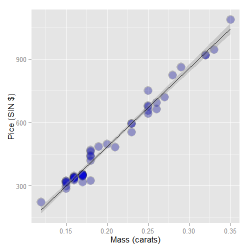

## Getting a more interpretable intercept

```r
fit2 <- lm(price ~ I(carat - mean(carat)), data = diamond)
coef(fit2)
```

```
           (Intercept) I(carat - mean(carat))
                 500.1                 3721.0
```

Thus $500.1 is the expected price for the average sized diamond of the data (0.2042 carats).

## Predicting the price of a diamond

```r
newx <- c(0.16, 0.27, 0.34)
coef(fit)[1] + coef(fit)[2] * newx
```

```
[1]  335.7  745.1 1005.5
```

```r
predict(fit, newdata = data.frame(carat = newx))
```

```
     1      2      3
 335.7  745.1 1005.5
```

Predicted values at the observed Xs (red) and at the new Xs (lines)

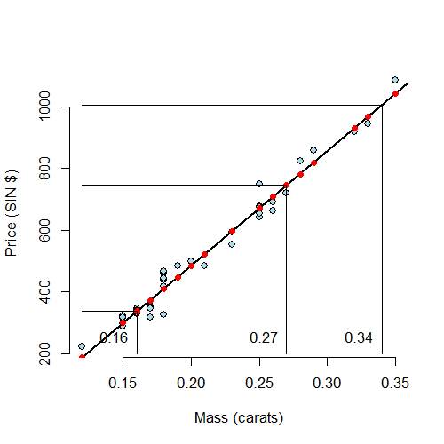